# Reproducible research peer assignment 1

# Imputing missing values

### 1. Calculate and report the total number of missing values in the dataset (i.e. the total number of rows with NAs)

```r
sum(is.na(activitydata$steps))
```

```
## [1] 2304
```

### 2.Devise a strategy for filling in all of the missing values in the dataset.

### 3. Create a new dataset that is equal to the original dataset but with the missing data filled in.

#### NOTE; opted for imputing with median, which is the default of the oimpute function of the Hmisc package.

```r
activitydataimputed <- activitydata
activitydataimputed$steps <- impute(activitydata$steps)
```

### 4. Make a histogram of the total number of steps taken each day

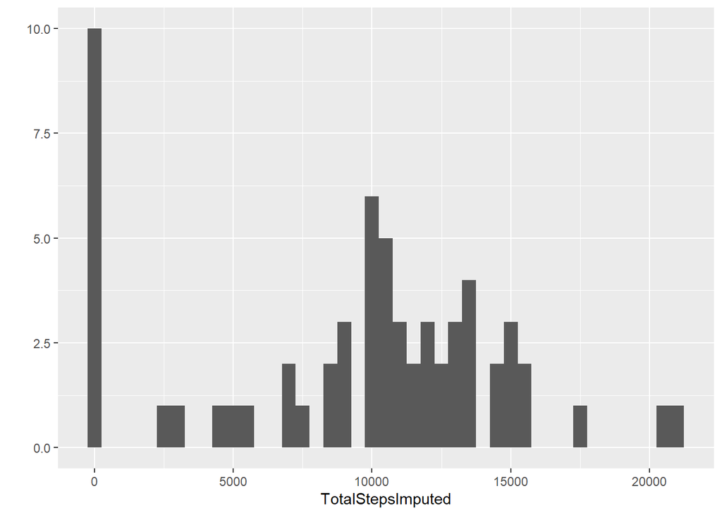

```r
TotalStepsImputed <- tapply(activitydataimputed$steps, activitydataimputed$date, sum, na.rm=T)
qplot(TotalStepsImputed, binwidth=500)
```

### Calculate and report the mean and median total number of steps taken per day

```r
TotalStepImputedMean <- mean(TotalStepsImputed)
TotalStepsImputedMedian <- median(TotalStepsImputed)
TotalStepImputedMean
```

```
## [1] 9354.23
```

```r
TotalStepsImputedMedian
```

```
## [1] 10395
```

# Are there differences in activity patterns between weekdays and weekends?

### Create a new factor variable in the dataset with two levels -- "weekday" and "weekend" indicating whether a given date is a weekday or weekend day.

```r
activitydataimputed$asDate <- as.Date(activitydataimputed$date)
activitydataimputed$day <- weekdays(activitydataimputed$asDate)
activitydataimputed$daytype <- ifelse(activitydataimputed$day %in% c("Saturday", "Sunday"), "weekend", "weekday")
```

### Make a panel plot containing a time series plot (i.e. type = "l") of the 5-minute interval (x-axis) and the average number of steps taken, averaged across all weekday days or weekend days (y-axis).

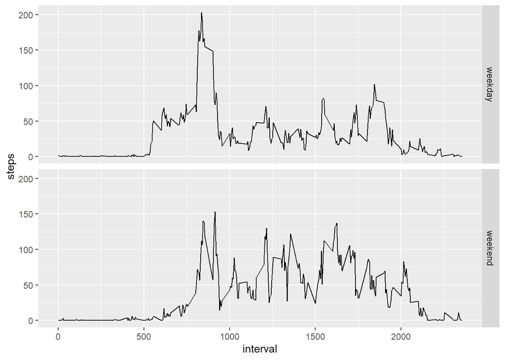

```r
ActIntervalImputedAndByDaytype <- aggregate(steps ~ interval + daytype, data=activitydataimputed, FUN=mean, na.rm=T)
ggplot(ActIntervalImputedAndByDaytype, aes(x=interval, y=steps))+geom_line()+ facet_grid(daytype ~ .)
```